# Практична робота №6

## **Тема. Графи. Найкоротші шляхи**

## **Мета:** набути практичних навичок розв’язання задач пошуку найкоротших шляхів у графі та оцінювання їх асимптотичної складності.

## **Варіант:** 7

## Завдання

### **7.** Задача з вар. 3, але за алгоритмом Белмена–Форда.

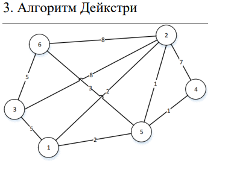

## Розв'язання

### Розв'язання задачі за алгоритмом Беллмана-Форда

#### Граф

- **Вершини**: $1, 2, 3, 4, 5, 6$
- **Ребра** (з вагами):
  - $1 \to 2$: $2$
  - $1 \to 3$: $5$
  - $1 \to 5$: $2$
  - $2 \to 4$: $7$
  - $2 \to 5$: $1$
  - $2 \to 6$: $8$
  - $3 \to 2$: $8$
  - $3 \to 6$: $5$
  - $4 \to 5$: $1$
  - $5 \to 6$: $3$

#### Ініціалізація

1. Відстані від вершини $1$ до всіх інших ініціалізуємо як $\infty$, окрім самої вершини $1$, яка має відстань $0$: $ \text{dist} = \{ 1: 0, 2: \infty, 3: \infty, 4: \infty, 5: \infty, 6: \infty \} $
2. Виконуємо релаксацію кожного ребра $n-1 = 5$ разів, де $n = 6$ (кількість вершин).

#### Ітерації

##### 1-а ітерація:

- Релаксуємо всі ребра:
  - $1 \to 2$: $\text{dist}[2] = \min(\infty, 0 + 2) = 2$
  - $1 \to 3$: $\text{dist}[3] = \min(\infty, 0 + 5) = 5$
  - $1 \to 5$: $\text{dist}[5] = \min(\infty, 0 + 2) = 2$
  - $2 \to 4$: $\text{dist}[4] = \min(\infty, 2 + 7) = 9$
  - $2 \to 5$: $\text{dist}[5] = \min(2, 2 + 1) = 2$ (не змінюється)
  - $2 \to 6$: $\text{dist}[6] = \min(\infty, 2 + 8) = 10$
  - $3 \to 2$: $\text{dist}[2] = \min(2, 5 + 8) = 2$ (не змінюється)
  - $3 \to 6$: $\text{dist}[6] = \min(10, 5 + 5) = 10$ (не змінюється)
  - $4 \to 5$: $\text{dist}[5] = \min(2, 9 + 1) = 2$ (не змінюється)
  - $5 \to 6$: $\text{dist}[6] = \min(10, 2 + 3) = 5$

Після першої ітерації: $ \text{dist} = \{ 1: 0, 2: 2, 3: 5, 4: 9, 5: 2, 6: 5 \} $

##### 2-а ітерація:

Після другої ітерації: $ \text{dist} = \{ 1: 0, 2: 2, 3: 5, 4: 3, 5: 2, 6: 5 \} $

##### 3-я, 4-а, 5-а ітерації:

Подальші релаксації не змінюють відстані, оскільки всі найкоротші шляхи вже знайдені.

#### Результат

Найкоротші відстані від вершини $1$ до всіх інших:

- $1 \to 1$: $0$
- $1 \to 2$: $2$
- $1 \to 3$: $5$
- $1 \to 4$: $3$
- $1 \to 5$: $2$
- $1 \to 6$: $5$

```python
# Перевірка алгоритму Беллмана-Форда для знаходження найкоротших шляхів у безнапрямковому графі

edges = [
    (1, 2, 2),
    (1, 3, 5),
    (1, 5, 2),
    (2, 5, 1),
    (2, 4, 7),
    (2, 6, 8),
    (3, 2, 8),
    (3, 6, 5),
    (4, 5, 1),
    (5, 6, 3)
]

# Для безнапрямкового графа додаємо обидва напрямки для кожного ребра
edges += [(v, u, w) for u, v, w in edges]

# Ініціалізація
vertices = [1, 2, 3, 4, 5, 6]  # Вершини графа
inf = float('inf')  # Позначення нескінченності
dist = {v: inf for v in vertices}  # Словник відстаней
dist[1] = 0  # Відстань від 1-ї вершини до себе = 0

# Функція для виконання алгоритму Беллмана-Форда
def bellman_ford(edges, vertices, dist):
    # Виконати n-1 ітерацій
    for _ in range(len(vertices) - 1):
        # Для кожного ребра перевіряємо, чи можемо покращити відстань
        for u, v, w in edges:
            if dist[u] + w < dist[v]:
                dist[v] = dist[u] + w
    return dist

# Запуск алгоритму
distances = bellman_ford(edges, vertices, dist)

# Виведення результатів
for v in vertices:
    print(f"Відстань від вершини 1 до вершини {v}: {distances[v]}")
```

```
Відстань від вершини 1 до вершини 1: 0
Відстань від вершини 1 до вершини 2: 2
Відстань від вершини 1 до вершини 3: 5
Відстань від вершини 1 до вершини 4: 3
Відстань від вершини 1 до вершини 5: 2
Відстань від вершини 1 до вершини 6: 5
```

## Контрольні питання

### 1. Що таке граф і які головні складові його структури?

Граф — це математична структура, що складається з набору вершин (також відомих як вузли) та набору ребер (або зв'язків) між ними.

#### Основні складові графа:

##### 1. **Вершини (V)**:

- Вершини є основними об'єктами графа, які можуть представляти будь-які сутності (наприклад, точки, об'єкти або організації).

##### 2. **Ребра (E)**:

- Ребра є з'єднаннями між вершинами, що можуть бути орієнтованими або неорієнтованими.
- **Орієнтовані графи**: Ребра мають напрямок від однієї вершини до іншої.
- **Неорієнтовані графи**: Ребра не мають напрямку, вони з'єднують вершини в обох напрямках.

##### 3. **Вага (optional)**:

- У деяких графах ребра можуть мати вагу (наприклад, відстань або вартість), що додає додаткову інформацію про зв'язки між вершинами.

##### 4. **Структура графа**:

- **Ациклічні графи**: Графи без циклів.
- **Циклічні графи**: Графи, що містять цикли.

### 2. Які алгоритми використовуються для пошуку найкоротших шляхів у графах?

#### Алгоритми для пошуку найкоротших шляхів у графах:

1. Алгоритм Дейкстри:
2. Алгоритм Белмана-Форда:
3. Алгоритм Флойда-Форшала:
4. Алгоритм А* (A-star):

### 3. Як працює алгоритм Дейкстри і які його особливості?

#### Принцип роботи:

1. **Ініціалізація**:
   - Встановлюється початкова відстань до початкової вершини рівною 0, а до всіх інших вершин — нескінченність.
   - Мітки всіх вершин позначаються як неперевірені.
2. **Вибір вершини з найменшою відстанню**:
   - З множини неперевірених вершин вибирається вершина з найменшою поточною відстанню.
3. **Оновлення відстаней**:
   - Для всіх сусідніх вершин поточної вибраної, якщо через поточну вершину можна знайти коротший шлях, оновлюється відстань.
4. **Повторення кроків**:
   - Повторюється кроки 2 і 3, поки всі вершини не будуть перевірені.
5. **Завершення**:
   - Алгоритм завершується, коли всі вершини оброблені або коли мінімальна відстань до незвіданої вершини нескінченна (що означає відсутність шляху).

#### Особливості:

1. **Використання черги з пріоритетами**:
   - Для вибору вершини з найменшою відстанню алгоритм часто використовує **чергу з пріоритетами** (heap), що дозволяє знизити складність вибору мінімального елементу до $O(\log V)$.
2. **Обмеження на ваги ребер**:
   - Алгоритм Дейкстри працює тільки з **невід'ємними вагами** на ребрах. Якщо є від'ємні ваги, алгоритм може працювати неправильно.
3. **Одноразовий запуск**:
   - Алгоритм знаходить найкоротший шлях від однієї вершини до всіх інших, а не від усіх до всіх (це робить алгоритм Флойда-Уоршелла).

#### Складність часу:

- **За допомогою черги з пріоритетами**: $O((V + E) \log V)$.

### 4. Що таке алгоритм Белмена–Форда і коли його варто застосовувати?

#### Алгоритм Белмена-Форда: принцип роботи та застосування

#### Принцип роботи:

1. **Ініціалізація**:
   - Встановлюється відстань до початкової вершини рівною 0, а до всіх інших вершин — нескінченність.
2. **Ітерації**:
   - Алгоритм виконує $V-1$ ітерацій, де в кожній ітерації перевіряються всі ребра графа.
   - Для кожного ребра $(u, v)$, якщо відстань до вершини $v$ через $u$ менша, ніж поточна відстань, то відстань оновлюється.
3. **Перевірка на від'ємні цикли**:
   - Після $V-1$ ітерацій алгоритм виконує ще одну перевірку. Якщо є ребра, де можна ще оновити відстань, то граф містить від'ємний цикл.

#### Коли застосовувати:

1. **Графи з від'ємними вагами**:
   - Алгоритм Белмена-Форда є єдиним популярним методом для знаходження найкоротших шляхів у графах з **від'ємними вагами** на ребрах.
2. **Виявлення від'ємних циклів**:
   - Алгоритм також використовується для виявлення **від'ємних циклів** в графах, які можуть бути важливими для задач оптимізації або теорії графів.
3. **Менша ефективність у порівнянні з Дейкстрою**:
   - Алгоритм Белмена-Форда менш ефективний за **алгоритм Дейкстри** для графів з невід'ємними вагами, оскільки його складність більша ($O(VE)$), але він підходить для випадків, коли є від'ємні ваги.

#### Складність часу:

- **Часова складність**: $O(VE)$, де $V$ — кількість вершин, а $E$ — кількість ребер.

### 5. Як працює алгоритм Флойда–Форшала і які його переваги та недоліки?

#### Алгоритм Флойда-Форшала: принцип роботи та переваги/недоліки

#### Принцип роботи:

1. **Ініціалізація**:
   - Створюється матриця відстаней між усіма парами вершин. Спочатку відстань між кожною парою вершин $i$ та $j$ дорівнює ваги ребра між ними, або нескінченність, якщо ребра немає. Відстань між кожною вершиною і самою собою дорівнює нулю.
2. **Ітерації**:
   - Алгоритм виконує трійку вкладених циклів:
     - Для кожної вершини $k$ перевіряються всі пари вершин $i$ і $j$.
     - Якщо відстань через вершину $k$ є коротшою, ніж поточна відстань між $i$ та $j$, то відстань оновлюється: $$ d(i, j) = \min(d(i, j), d(i, k) + d(k, j)) $$
3. **Завершення**:
   - Після виконання всіх ітерацій матриця відстаней містить найкоротші шляхи між усіма парами вершин.

#### Переваги:

1. **Всі пари найкоротших шляхів**:
   - Алгоритм знаходить найкоротші шляхи між усіма парами вершин, що робить його універсальним для задач, де потрібна така інформація.
2. **Підтримка від'ємних ваг**:
   - Алгоритм Флойда-Форшала працює з графами, які містять від'ємні ваги на ребрах, якщо тільки в графі немає від'ємних циклів.
3. **Простота**:
   - Алгоритм є простим у реалізації, оскільки використовує лише матрицю відстаней та три вкладених цикли.

#### Недоліки:

1. **Часова складність**:
   - Часова складність алгоритму становить $O(V^3)$, що робить його неефективним для дуже великих графів.
2. **Пам'ятевитратність**:
   - Алгоритм вимагає зберігання матриці $V \times V$, що може бути непрактичним для великих графів.
3. **Відсутність оптимізації для одиночних шляхів**:
   - Якщо потрібно знайти лише найкоротший шлях між однією парою вершин, то алгоритм Флойда-Форшала буде неефективним у порівнянні з іншими методами, такими як алгоритм Дейкстри.

#### Складність часу:

- **Часова складність**: $O(V^3)$, де $V$ — кількість вершин у графі.